# StatBI_practice_PCA_in_R

Zhozhikov Leonid

12/9/2021

[figure not shown]

Welcome to my report!

```r
library(readxl)
library(vegan)
library(dplyr)
```

```r
library(ggplot2)
library(grid)
library(ggpubr)
library(factoextra)
library(knitr)
library(magrittr)
library(caret)
library(clusterSim)
```

## First things first

```r
reader <-  function(f_ext, PATH) {
  lst_files <- list.files(PATH, pattern = paste('*.', f_ext, sep = ''))
  df <-  read.csv(paste(PATH, lst_files[1], sep = ''))
  for (i in lst_files[-1]) df <- merge(df, read.csv(paste(PATH, i, sep = '')))
  return(df)
}

df <- reader('csv', PATH= './/Data//')

df_ver1 <- dplyr::select(df, -c(material))
```

## Journey to nowhere

#### Here I tried to standartize data by four diffrent ways but no idea why, because in the end I saw no diffrence between standartized data and not

```r
train_size <- sample(seq_len(nrow(df_ver1)), size = floor(0.75 * nrow(df_ver1)))

train_data <- df_ver1[train_size, ]
test_data <- df_ver1[-train_size, ]
#

#train_data

### 11111 var

## find mean and sd column-wise of training data
train_data_mean <- apply(train_data,2,mean)
train_data_sd <- apply(train_data,2,sd)

## centered
#?sweep
sweepss <- sweep(train_data, 2L, train_data_mean) # using the default "-" to subtract mean column-wise
## centered AND scaled
norm2.test_data <- sweep(sweepss, 2, train_data_sd, "/")
```

### 2 variant

#normParam <- preProcess(train_data) #norm.test_data <- predict(normParam, test_data)

### 3 variant

#glimpse(train_data)

#preproc1 <- preProcess(train_data[,c(2:168)], method=c(“range”))

#norm_one.train_data <- predict(preproc1, train_data[,c(2:168)])

#glimpse(norm_one.train_data)

#second #preproc2 <- preProcess(test_data[,c(2:168)], method=c(“range”))

#norm_one.test_data <- predict(preproc1, test_data[,c(2:168)])

#glimpse(norm_one.test_data)

### 4 variant

#norm_two.test_data <- as.data.frame(scale(train_data[,c(2:168)]))

#glimpse(norm_two.test_data)

#nwdf = cbind(train_data$critical_temp, norm_one.train_data)

#model <- lm(nwdf$`train_data$critical_temp`~., data = nwdf) #summary(model)

# Here is battleground of me trying to perform PCA experiments!

#pca <- prcomp(norm_one.train_data)

#pcr_tot <- pca$x #pca2 <- pca$x[,2] #pca3 <- pca$x[,3] #pca4 <- pca$x[,4] #pca5 <- pca$x[,5] #pca6 <- pca$x[,6]

#pca_total <- data.frame(cbind(train_data$critical_temp, pcr_tot))

#model_pca <- lm(pca_total$V1 ~., data = pca_total) #pca1 + pca2 + pca3 + pca4 + pca5 + pca6 #summary(model_pca)

###w/o standard#######################################################

#model_wos <- lm(train_data$critical_temp~., data = train_data) #summary(model_wos)

###w/o standard

#train_data_wotv <- subset(train_data, select = -c(1))

#pca_wos <- prcomp(train_data_wotv)

#summary(pca_wos)

#pca11 <- pca$x #pca22 <- pca$x[,2] #pca33 <- pca$x[,3] #pca44 <- pca$x[,4] #pca55 <- pca$x[,5] #pca66 <- pca$x[,6]

#pca_total_wos <- data.frame(cbind(train_data$critical_temp, pca11, pca22, pca33, pca44, pca55, pca66))

#model_pca_wos <- lm(scale(pca_total_wos$V1)~., data = pca_total_wos)

#summary(model_pca_wos)

## In the end here is the some kind of working data… (no)

```r
train_data.tv <- train_data$critical_temp
train_data$critical_temp <- NULL

train_data.norm <- data.Normalization(train_data, type="n1", normalization="column")
train_data.tv.norm <- data.Normalization(train_data.tv, type="n1", normalization="column")
```

```r
train_data.norm <- dplyr::select(train_data.norm,-c(He, Ne, Ar, Kr, Xe, Pm, Po, At, Rn))

train_data.pca <- prcomp(train_data.norm, center=TRUE, scale.=TRUE)

summary(train_data.pca)
```

```
## Importance of components:
##                           PC1     PC2     PC3     PC4     PC5     PC6     PC7
## Standard deviation     5.5704 3.12150 2.74713 2.53328 2.15419 1.91330 1.71220
## Proportion of Variance 0.1964 0.06167 0.04776 0.04062 0.02937 0.02317 0.01855
## Cumulative Proportion  0.1964 0.25806 0.30582 0.34644 0.37581 0.39898 0.41753
##                            PC8     PC9    PC10    PC11    PC12    PC13    PC14
## Standard deviation     1.59939 1.53722 1.48430 1.42307 1.37728 1.37466 1.35444
## Proportion of Variance 0.01619 0.01496 0.01394 0.01282 0.01201 0.01196 0.01161
## Cumulative Proportion  0.43372 0.44868 0.46262 0.47544 0.48744 0.49940 0.51101
##                           PC15    PC16    PC17   PC18    PC19    PC20    PC21
## Standard deviation     1.33880 1.30687 1.29122 1.2508 1.24804 1.23002 1.20719
## Proportion of Variance 0.01134 0.01081 0.01055 0.0099 0.00986 0.00958 0.00922
## Cumulative Proportion  0.52236 0.53317 0.54372 0.5536 0.56348 0.57306 0.58228
##                           PC22    PC23    PC24    PC25    PC26    PC27   PC28
## Standard deviation     1.18640 1.18263 1.15642 1.12372 1.12263 1.10735 1.0889
## Proportion of Variance 0.00891 0.00885 0.00846 0.00799 0.00798 0.00776 0.0075
## Cumulative Proportion  0.59119 0.60004 0.60850 0.61650 0.62447 0.63223 0.6397
##                           PC29    PC30    PC31    PC32   PC33    PC34    PC35
## Standard deviation     1.08498 1.07773 1.07159 1.06763 1.0591 1.04904 1.04143
## Proportion of Variance 0.00745 0.00735 0.00727 0.00721 0.0071 0.00697 0.00686
## Cumulative Proportion  0.64719 0.65454 0.66181 0.66902 0.6761 0.68309 0.68995
##                           PC36    PC37    PC38    PC39    PC40   PC41    PC42
## Standard deviation     1.03547 1.02661 1.02448 1.01940 1.01432 1.0130 1.00861
## Proportion of Variance 0.00679 0.00667 0.00664 0.00658 0.00651 0.0065 0.00644
## Cumulative Proportion  0.69674 0.70341 0.71005 0.71663 0.72314 0.7296 0.73607
##                           PC43   PC44    PC45    PC46    PC47    PC48    PC49
## Standard deviation     1.00774 1.0054 1.00415 1.00156 1.00075 1.00027 0.99964
## Proportion of Variance 0.00643 0.0064 0.00638 0.00635 0.00634 0.00633 0.00632
## Cumulative Proportion  0.74250 0.7489 0.75528 0.76163 0.76797 0.77430 0.78062
##                           PC50   PC51    PC52    PC53    PC54    PC55   PC56
## Standard deviation     0.99855 0.9980 0.99606 0.99257 0.98748 0.98357 0.9815
## Proportion of Variance 0.00631 0.0063 0.00628 0.00624 0.00617 0.00612 0.0061
## Cumulative Proportion  0.78694 0.7932 0.79952 0.80575 0.81193 0.81805 0.8242
##                           PC57    PC58    PC59    PC60    PC61   PC62    PC63
## Standard deviation     0.97631 0.97559 0.96790 0.96176 0.95234 0.9486 0.94307
## Proportion of Variance 0.00603 0.00602 0.00593 0.00585 0.00574 0.0057 0.00563
## Cumulative Proportion  0.83018 0.83620 0.84213 0.84799 0.85373 0.8594 0.86505
##                           PC64    PC65    PC66    PC67    PC68   PC69    PC70
## Standard deviation     0.92937 0.92597 0.92230 0.92009 0.91069 0.9067 0.89305
## Proportion of Variance 0.00547 0.00543 0.00538 0.00536 0.00525 0.0052 0.00505
```

[output cut: 38 more lines]

```
## Standard deviation     0.08827 0.08597 0.08376 0.07800 0.07455 0.06992 0.06099
## Proportion of Variance 0.00005 0.00005 0.00004 0.00004 0.00004 0.00003 0.00002
## Cumulative Proportion  0.99962 0.99967 0.99971 0.99975 0.99979 0.99982 0.99984
##                          PC141   PC142   PC143   PC144   PC145   PC146   PC147
## Standard deviation     0.05844 0.05628 0.05347 0.05229 0.04954 0.04592 0.04208
## Proportion of Variance 0.00002 0.00002 0.00002 0.00002 0.00002 0.00001 0.00001
## Cumulative Proportion  0.99986 0.99988 0.99990 0.99992 0.99993 0.99995 0.99996
##                          PC148   PC149   PC150  PC151   PC152   PC153   PC154
## Standard deviation     0.03998 0.03703 0.03373 0.0267 0.02512 0.02259 0.01867
## Proportion of Variance 0.00001 0.00001 0.00001 0.0000 0.00000 0.00000 0.00000
## Cumulative Proportion  0.99997 0.99998 0.99998 1.0000 0.99999 1.00000 1.00000
##                          PC155  PC156    PC157    PC158
## Standard deviation     0.01397 0.0107 0.008575 0.006965
## Proportion of Variance 0.00000 0.0000 0.000000 0.000000
## Cumulative Proportion  1.00000 1.0000 1.000000 1.000000
```

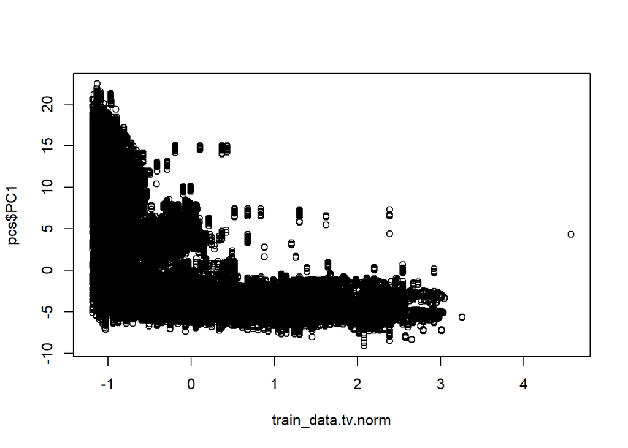

```r
pcs <- as.data.frame(train_data.pca$x)

train_data.pca_total <- cbind(train_data.tv.norm, pcs)

plot(train_data.tv.norm, pcs$PC1)
```

```r
lmodel <- lm(train_data.tv.norm ~ ., data = train_data.pca_total)

summary(lmodel)
```

```
##
## Call:
## lm(formula = train_data.tv.norm ~ ., data = train_data.pca_total)
##
## Residuals:
##     Min      1Q  Median      3Q     Max
## -6.8942 -0.2992  0.0266  0.3569  5.1282
##
## Coefficients:
##               Estimate Std. Error  t value Pr(>|t|)
## (Intercept)  2.941e-16  6.979e-04    0.000  1.00000
## PC1         -1.125e-01  1.253e-04 -897.823  < 2e-16 ***
## PC2         -3.370e-02  2.236e-04 -150.752  < 2e-16 ***
## PC3         -7.070e-02  2.540e-04 -278.303  < 2e-16 ***
## PC4         -5.153e-02  2.755e-04 -187.030  < 2e-16 ***
## PC5          6.062e-02  3.240e-04  187.104  < 2e-16 ***
## PC6          1.425e-01  3.648e-04  390.682  < 2e-16 ***
## PC7         -4.662e-03  4.076e-04  -11.437  < 2e-16 ***
## PC8          2.579e-02  4.364e-04   59.103  < 2e-16 ***
## PC9          7.822e-03  4.540e-04   17.229  < 2e-16 ***
## PC10        -9.301e-02  4.702e-04 -197.823  < 2e-16 ***
## PC11         1.063e-02  4.904e-04   21.685  < 2e-16 ***
## PC12         1.595e-02  5.067e-04   31.469  < 2e-16 ***
## PC13         9.848e-02  5.077e-04  193.982  < 2e-16 ***
## PC14        -2.793e-03  5.153e-04   -5.421 5.93e-08 ***
## PC15        -7.529e-02  5.213e-04 -144.430  < 2e-16 ***
## PC16        -8.296e-02  5.340e-04 -155.354  < 2e-16 ***
## PC17        -2.124e-02  5.405e-04  -39.294  < 2e-16 ***
## PC18        -1.565e-02  5.580e-04  -28.043  < 2e-16 ***
## PC19         1.316e-02  5.592e-04   23.541  < 2e-16 ***
## PC20        -4.114e-03  5.674e-04   -7.251 4.14e-13 ***
## PC21        -1.135e-03  5.781e-04   -1.963  0.04967 *
## PC22         5.928e-02  5.883e-04  100.770  < 2e-16 ***
## PC23        -4.373e-02  5.901e-04  -74.096  < 2e-16 ***
## PC24        -2.026e-02  6.035e-04  -33.575  < 2e-16 ***
## PC25        -2.439e-02  6.211e-04  -39.270  < 2e-16 ***
## PC26        -6.632e-03  6.217e-04  -10.668  < 2e-16 ***
## PC27        -4.273e-03  6.302e-04   -6.779 1.21e-11 ***
## PC28         1.501e-02  6.409e-04   23.415  < 2e-16 ***
## PC29        -2.405e-02  6.432e-04  -37.393  < 2e-16 ***
```

[output cut: 120 more lines]

```
## PC150        8.437e-01  2.069e-02   40.773  < 2e-16 ***
## PC151       -9.109e-01  2.614e-02  -34.848  < 2e-16 ***
## PC152       -6.650e-04  2.779e-02   -0.024  0.98091
## PC153       -9.129e-01  3.090e-02  -29.546  < 2e-16 ***
## PC154        2.289e-01  3.739e-02    6.122 9.24e-10 ***
## PC155        1.979e-01  4.996e-02    3.961 7.45e-05 ***
## PC156        1.633e+00  6.522e-02   25.041  < 2e-16 ***
## PC157        1.595e+00  8.139e-02   19.600  < 2e-16 ***
## PC158       -7.331e-01  1.002e-01   -7.316 2.55e-13 ***
## ---
## Signif. codes:  0 '***' 0.001 '**' 0.01 '*' 0.05 '.' 0.1 ' ' 1
##
## Residual standard error: 0.5113 on 536546 degrees of freedom
## Multiple R-squared:  0.7387, Adjusted R-squared:  0.7386
## F-statistic:  9599 on 158 and 536546 DF,  p-value: < 2.2e-16
```

## no idea what is the problem

```r
pca11 <- train_data.pca$x[,1]
pca22 <- train_data.pca$x[,2]
pca33 <- train_data.pca$x[,3]
pca44 <- train_data.pca$x[,4]
pca55 <- train_data.pca$x[,5]
pca66 <- train_data.pca$x[,6]
train_data.pca_total_cut <- data.frame(cbind(train_data.tv.norm, pca11, pca22, pca33, pca44, pca55, pca66))
lmodel_cut <- lm(train_data.tv.norm ~ ., data = train_data.pca_total_cut)
summary(lmodel_cut)
```

```
##
## Call:
## lm(formula = train_data.tv.norm ~ ., data = train_data.pca_total_cut)
##
## Residuals:
##     Min      1Q  Median      3Q     Max
## -3.5762 -0.4881  0.0012  0.4838  6.4024
##
## Coefficients:
##               Estimate Std. Error t value Pr(>|t|)
## (Intercept)  1.991e-16  9.158e-04     0.0        1
## pca11       -1.125e-01  1.644e-04  -684.2   <2e-16 ***
## pca22       -3.370e-02  2.934e-04  -114.9   <2e-16 ***
## pca33       -7.070e-02  3.334e-04  -212.1   <2e-16 ***
## pca44       -5.153e-02  3.615e-04  -142.5   <2e-16 ***
## pca55        6.062e-02  4.251e-04   142.6   <2e-16 ***
## pca66        1.425e-01  4.787e-04   297.7   <2e-16 ***
## ---
## Signif. codes:  0 '***' 0.001 '**' 0.01 '*' 0.05 '.' 0.1 ' ' 1
##
## Residual standard error: 0.6709 on 536698 degrees of freedom
## Multiple R-squared:  0.5498, Adjusted R-squared:  0.5498
## F-statistic: 1.093e+05 on 6 and 536698 DF,  p-value: < 2.2e-16
```

[figure not shown]

Welcome to the end!